# 2023 global fishing activity

The Invisible Ocean | A. Spatial distribution

**T01 Annual map** **T02 FAO areas** **T03 Concentration**

**111.71 million hours** of estimated fishing activity across **1,193,301 active grid cells** in 2023. Each grid covers 0.1° by 0.1° and can include activity from multiple vessels.

## T01 · Annual grid map

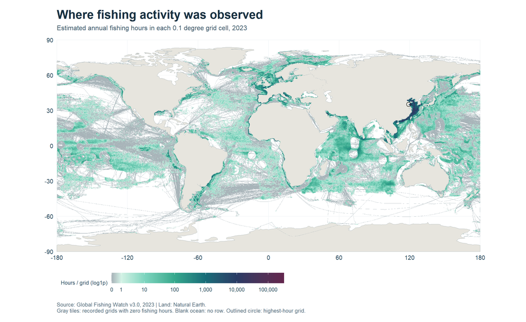

The highest-hour grid was centred at **119.35° E, 35.05° N** near the coast of eastern China, with **316,398.92 hours**. The Northwest Pacific accounts for a large share of the global total, as the regional comparison below quantifies. Of the 2,040,786 grid cells recorded in the dataset, 847,485 had zero estimated fishing hours.

## T02 · FAO marine area totals

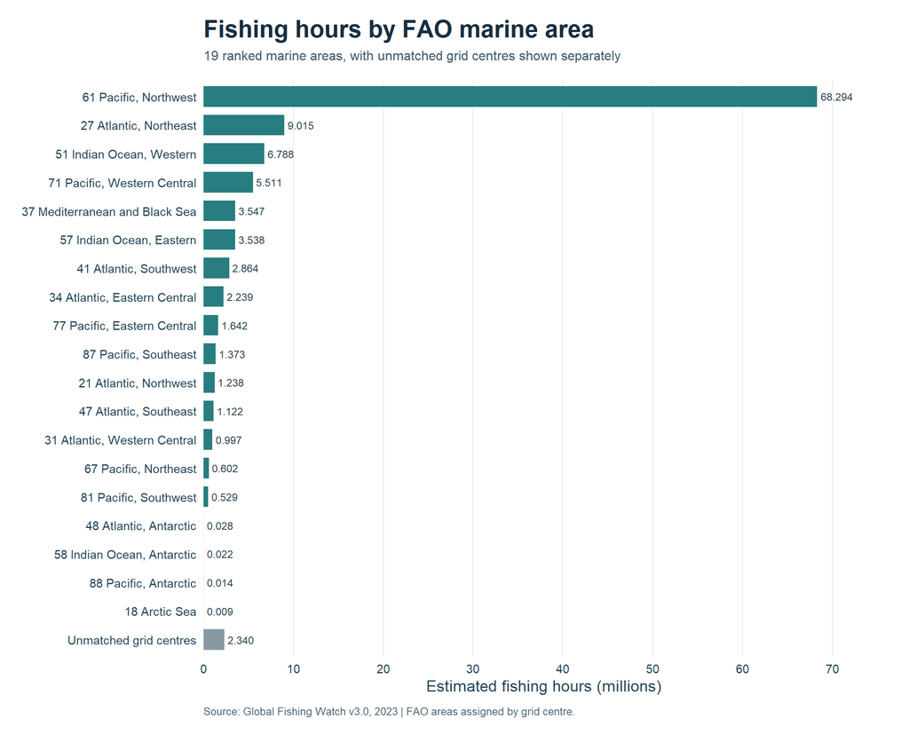

The **Northwest Pacific (61)** recorded **68.29 million hours**, or **61.13% of the global total**. The **Northeast Atlantic (27)** and **Western Indian Ocean (51)** followed with 9.01 and 6.79 million hours, respectively. The global denominator includes 2.34 million hours (2.09%) from grid centres outside the FAO marine polygons.

## T03 · Fishing-hour concentration

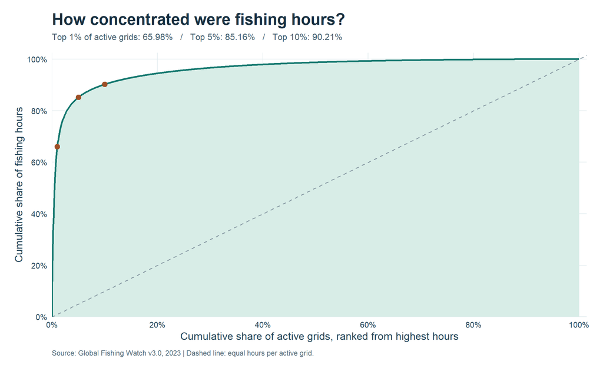

| Top share of active grids | Grid count | Cumulative hours | Share of global hours |
| --- | --- | --- | --- |
| 1% | 11,934 | 73,709,522.28 | 65.98% |
| 5% | 59,666 | 95,131,852.29 | 85.16% |
| 10% | 119,331 | 100,770,087.68 | 90.21% |

Ranking is based on annual hours, with ties ordered by `grid_id`. A cell is active if its annual hours are positive. Each cutoff rounds up to a whole grid, and the cumulative curve ends at 100%. Shares describe a percentage of **active grid cells**. The physical area of a 0.1° cell varies by latitude.

## Sources and interpretation

Global Fishing Watch estimates apparent fishing activity from AIS observations. AIS reception and classification vary by location. Report the results as **estimated hours in the observed data**. The regional chart compares total hours and does not adjust for region size.

- [Global Fishing Watch v3.0 dataset and documentation](https://doi.org/10.5281/zenodo.14982712)
- [FAO marine fishing areas](https://www.fao.org/cwp-on-fishery-statistics/handbook/general-concepts/main-water-areas)
- [Natural Earth land polygons](https://www.naturalearthdata.com/downloads/110m-physical-vectors/110m-land/)